# Notebook

Exploratory Data Analysis (EDA) Report

Importing Required Libraries

This step imports essential Python libraries for data processing, visualization, and statistical analysis. pandas and numpy handle structured data, matplotlib and seaborn support visualization, and statsmodels and sklearn provide statistical and machine learning functionalities. Suppressing warnings ensures a cleaner output.

```python
# Import required libraries
import pandas as pd
import numpy as np
import matplotlib.pyplot as plt
import seaborn as sns
import plotly.express as px
from statsmodels.tsa.seasonal import seasonal_decompose
from sklearn.decomposition import PCA
from sklearn.cluster import KMeans
from sklearn.preprocessing import StandardScaler
from statsmodels.tsa.stattools import adfuller
import warnings
warnings.filterwarnings('ignore')
```

The dataset is loaded into a Pandas DataFrame from a CSV file. This dataset contain Zillow Home Value Index (ZHVI) data across different regions. Loading this data is the first step in understanding the housing market trends.

```python
# Load the dataset
df = pd.read_csv('/content/County_zhvi_bdrmcnt_2_uc_sfrcondo_tier_0.33_0.67_sm_sa_month.csv')
```

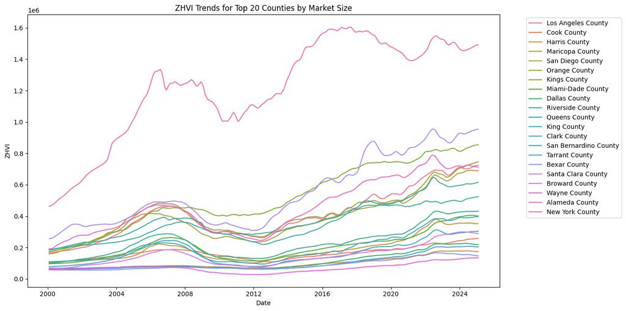

```python
# Convert wide format to long format
melted_df = pd.melt(
    df,
    id_vars=['RegionID', 'SizeRank', 'RegionName', 'RegionType', 'StateName', 'State', 'Metro', 'StateCodeFIPS', 'MunicipalCodeFIPS'],
    var_name='Date',
    value_name='ZHVI'
)
melted_df['Date'] = pd.to_datetime(melted_df['Date'])

# Filter top 20 counties by SizeRank
top_counties = melted_df[melted_df['SizeRank'] <= 20]

# Time Series Visualization
plt.figure(figsize=(14, 7))
sns.lineplot(data=top_counties, x='Date', y='ZHVI', hue='RegionName')
plt.title('ZHVI Trends for Top 20 Counties by Market Size')
plt.legend(bbox_to_anchor=(1.05, 1), loc='upper left')
plt.tight_layout()
plt.show()
```

Time Series Decomposition (Los Angeles County)

Seasonal decomposition is applied to ZHVI data from Los Angeles County, breaking it into trend, seasonal, and residual components. The trend component shows long-term movements, the seasonal component highlights regular fluctuations, and the residual captures anomalies. This analysis is useful in identifying cyclical patterns and market stability.

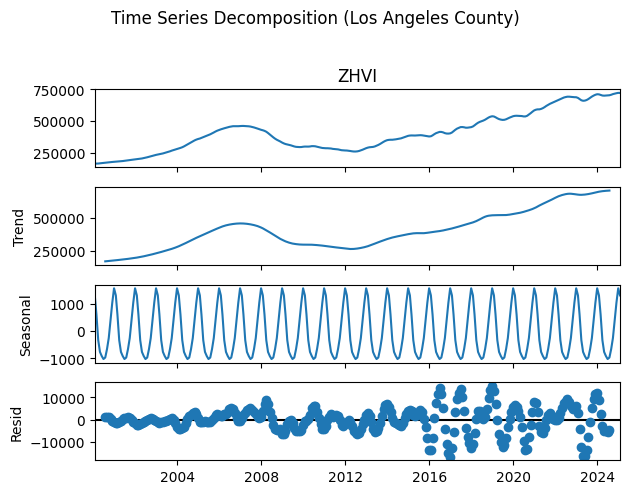

```python
la_county = melted_df[melted_df['RegionName'] == 'Los Angeles County'].set_index('Date')
result = seasonal_decompose(la_county['ZHVI'], model='additive', period=12)
result.plot()
plt.suptitle('Time Series Decomposition (Los Angeles County)', y=1.02)
plt.tight_layout()
plt.show()
```

K-Means Clustering for Market Segmentation

K-Means clustering groups counties based on ZHVI patterns, identifying three distinct market segments. The results are visualized using Principal Component Analysis (PCA), where each cluster is represented in a two-dimensional space. This analysis helps classify housing markets into distinct categories, which can be useful for investors and policymakers.

[figure not shown]

```python
# K-Means clustering
kmeans = KMeans(n_clusters=3, random_state=42)
clusters = kmeans.fit_predict(scaled_data)

# Visualize clusters
pca_df['Cluster'] = clusters
plt.figure(figsize=(10, 8))
sns.scatterplot(data=pca_df, x='PC1', y='PC2', hue='Cluster', palette='viridis', s=100)
plt.title('Market Segmentation via K-Means Clustering')
plt.show()
```

Stationarity Check (Augmented Dickey-Fuller Test)

The Augmented Dickey-Fuller (ADF) test checks whether the time series is stationary. A low p-value (<0.05) suggests stationarity, meaning the housing market follows a predictable trend. If the data is non-stationary, transformations like differencing may be required for further analysis.

```python
# Stationarity Check (ADF Test)
def adf_test(series):
    result = adfuller(series.dropna())
    return pd.Series({
        'ADF Statistic': result[0],
        'p-value': result[1],
        'Critical (1%)': result[4]['1%']
    })

stationarity = pivot_df.apply(adf_test).T
print(stationarity.sort_values('p-value'))
```

[output not shown]

Interactive Time Series Analysis

A Plotly-based interactive line chart allows users to explore ZHVI trends dynamically. Users can hover over data points to see additional details, making it easier to compare market fluctuations across different counties.

```python
# Interactive time series
fig = px.line(top_counties, x='Date', y='ZHVI', color='RegionName',
              title='Interactive ZHVI Analysis',
              hover_data=['State', 'Metro'])
fig.update_layout(hovermode='x unified')
fig.show()
```

[interactive chart not shown]

Filtering Data from 2020 Onwards

```python
# Filter data from 2020 onwards
df_2020 = melted_df[melted_df['Date'] >= '2020-01-01']
df_2020 = df_2020.dropna(subset=['ZHVI'])

# Select top 5 counties for clearer visualization
top5_counties = df_2020[df_2020['SizeRank'] <= 5]
```

Distribution Analysis of ZHVI (2020-Present)

A histogram with a KDE curve visualizes the distribution of ZHVI values. Skewness and kurtosis values are calculated to measure asymmetry and tail behavior. Additionally, a box plot shows county-wise ZHVI distributions, helping identify outliers and variations in home values.

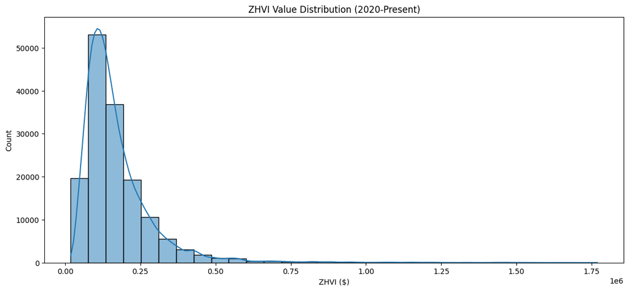

```
Skewness: 3.53
Kurtosis: 22.82
```

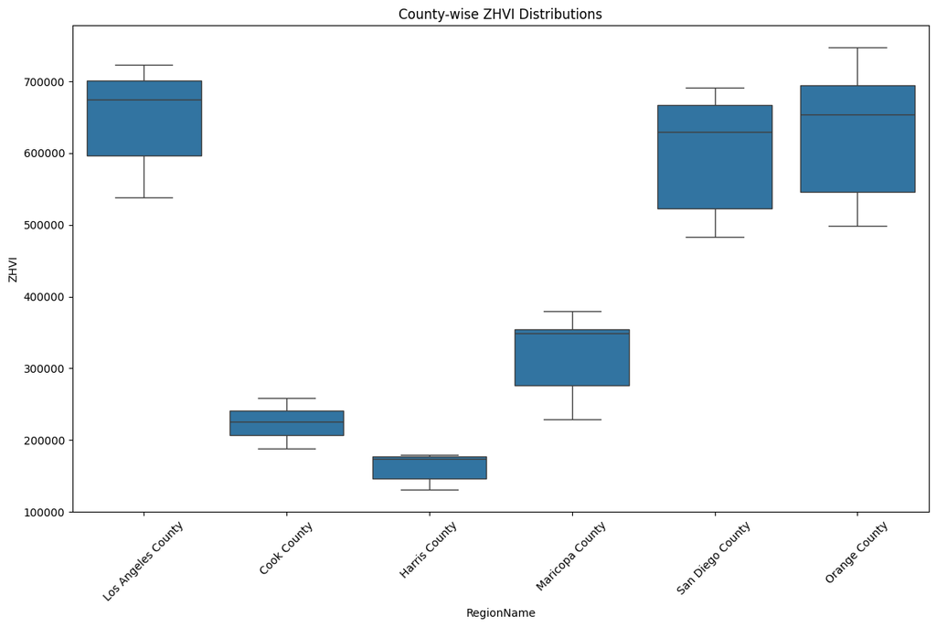

```python
plt.figure(figsize=(14, 6))
sns.histplot(df_2020['ZHVI'], kde=True, bins=30)
plt.title('ZHVI Value Distribution (2020-Present)')
plt.xlabel('ZHVI ($)')
plt.show()

print(f"Skewness: {df_2020['ZHVI'].skew():.2f}")
print(f"Kurtosis: {df_2020['ZHVI'].kurtosis():.2f}")

# County-wise distributions
plt.figure(figsize=(14, 8))
sns.boxplot(data=top5_counties, x='RegionName', y='ZHVI')
plt.title('County-wise ZHVI Distributions')
plt.xticks(rotation=45)
plt.show()
```

Post-COVID Market Trajectories & Growth Rate Analysis

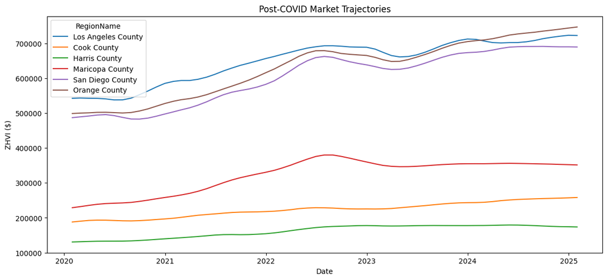

```
                             min           max     Growth%
RegionName
Summit County       85239.412015  9.410613e+05  847.688249
San Miguel County  142984.549808  1.193095e+06  663.390836
Custer County       51238.357001  4.302185e+05  469.534541
Curry County        80189.622004  4.277793e+05  425.993328
Madison County      58590.895103  5.314738e+05  359.133060
```

```python
# Time vs ZHVI
plt.figure(figsize=(14, 6))
sns.lineplot(data=top5_counties, x='Date', y='ZHVI', hue='RegionName')
plt.title('Post-COVID Market Trajectories')
plt.ylabel('ZHVI ($)')
plt.show()

# Growth Rate Analysis
# Growth Rate Analysis
growth = df_2020.groupby('RegionName')['ZHVI'].agg(
    ['min','max', lambda x: (x.iloc[-1]/x.iloc[0]-1)*100]
)
growth.columns = ['min', 'max', 'Growth%']  # Rename columns immediately after aggregation
print(growth.sort_values('Growth%', ascending=False).head())
```

County-Wise Correlation Matrix

A heatmap of the correlation matrix shows relationships between housing markets in different counties. High correlation values suggest synchronized price movements, while low correlations indicate independent trends.

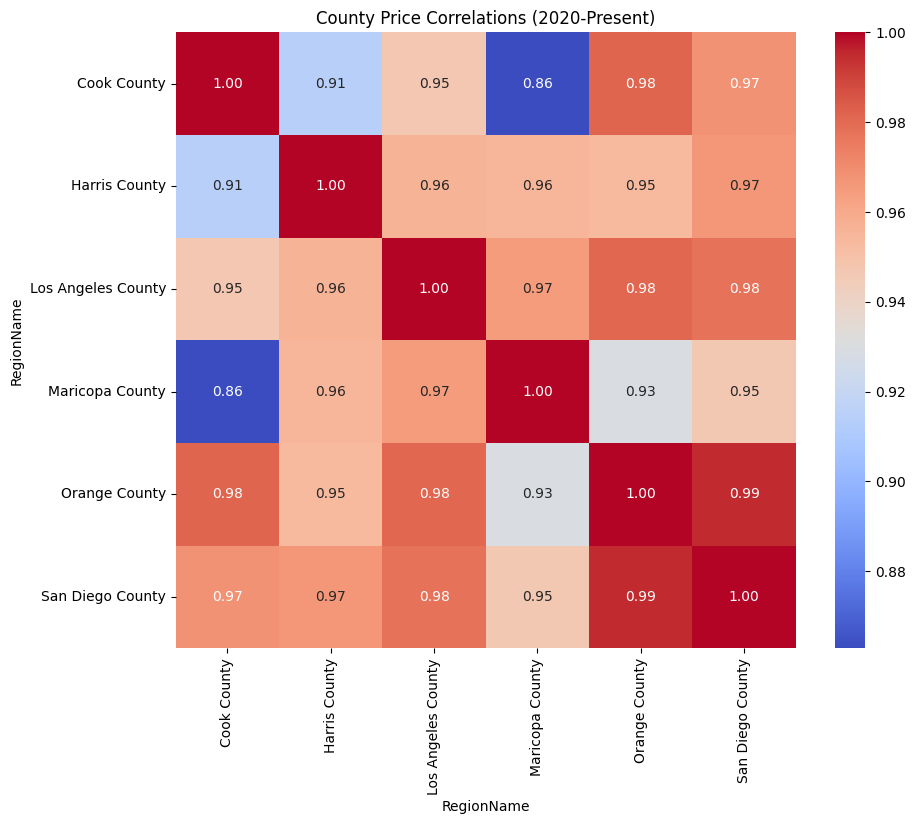

```python
# Monthly correlation matrix
corr_matrix = top5_counties.pivot_table(
    index='Date', columns='RegionName', values='ZHVI'
).corr()

plt.figure(figsize=(10, 8))
sns.heatmap(corr_matrix, annot=True, cmap='coolwarm', fmt='.2f')
plt.title('County Price Correlations (2020-Present)')
plt.show()
```

Linear Regression for Los Angeles County

Linear regression is applied to model ZHVI trends in Los Angeles County. The fitted line estimates the overall market trend, and the R² score measures how well the model explains price variations over time.

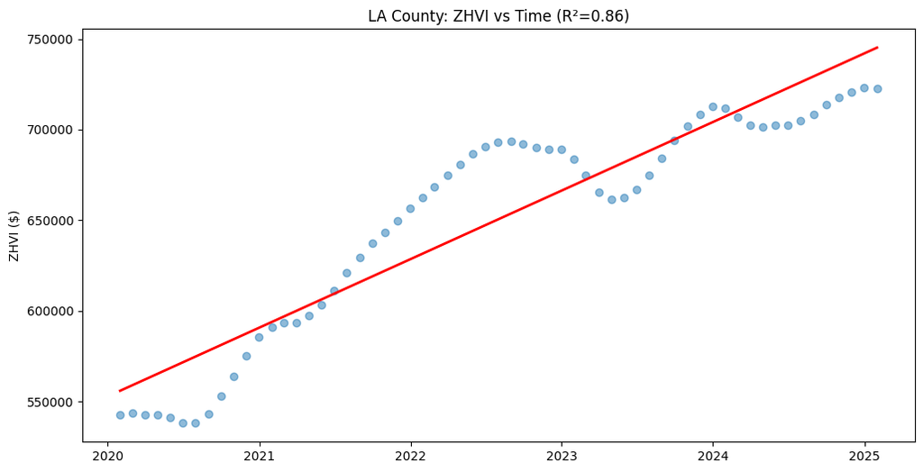

```python
from sklearn.linear_model import LinearRegression

# Prepare data for LA County
la = df_2020[df_2020['RegionName'] == 'Los Angeles County']
X = np.array((la['Date'] - la['Date'].min()).dt.days).reshape(-1, 1)
y = la['ZHVI'].values

model = LinearRegression()
model.fit(X, y)

# Plot results
plt.figure(figsize=(12, 6))
plt.scatter(la['Date'], y, alpha=0.5)
plt.plot(la['Date'], model.predict(X), color='r', lw=2)
plt.title(f'LA County: ZHVI vs Time (R²={model.score(X,y):.2f})')
plt.ylabel('ZHVI ($)')
plt.show()
```

Logistic Regression for Price Increase Prediction

Logistic regression is used to predict whether ZHVI will increase in a given month. The model outputs probability estimates for price increases, helping investors anticipate market shifts.

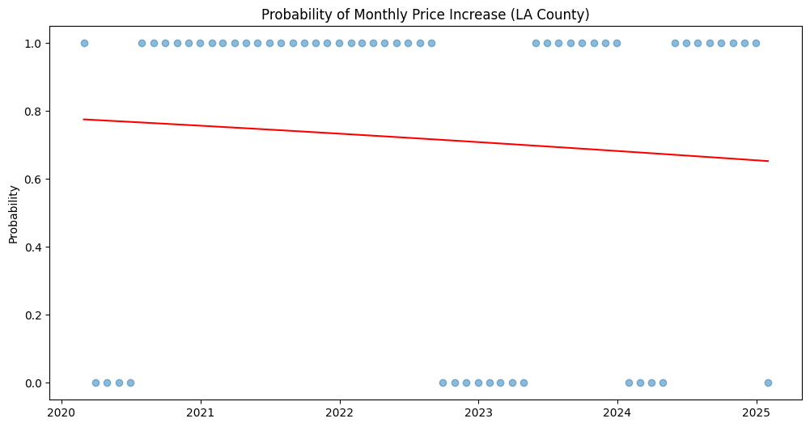

```python
from sklearn.linear_model import LogisticRegression

# Create binary target: 1 if price increased from previous month
la['Increase'] = (la['ZHVI'].diff() > 0).astype(int)
X = np.array((la['Date'] - la['Date'].min()).dt.days).reshape(-1, 1)
y = la['Increase'].iloc[1:]

model = LogisticRegression()
model.fit(X[1:], y)

# Calculate probability curve
# Use the actual date range instead of a linear space
probs = model.predict_proba(X[1:])[:, 1]

plt.figure(figsize=(12, 6))
plt.scatter(la['Date'].iloc[1:], y, alpha=0.5)
plt.plot(la['Date'].iloc[1:], probs, color='r')
plt.title('Probability of Monthly Price Increase (LA County)')
plt.ylabel('Probability')
plt.show()
```

Seasonal Decomposition for a Sample County

A selected county's ZHVI data undergoes seasonal decomposition to identify trends, cyclic patterns, and anomalies. This analysis is critical for understanding periodic market fluctuations.

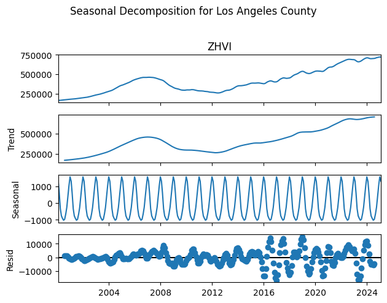

```python
# 1. Seasonal Decomposition for a Sample County
county_name = top_counties['RegionName'].iloc[0]
county_data = top_counties[top_counties['RegionName'] == county_name].set_index('Date')['ZHVI']

# Perform seasonal decomposition
decomposition = seasonal_decompose(county_data, model='additive', period=12)
plt.figure(figsize=(14, 8))
decomposition.plot()
plt.suptitle(f'Seasonal Decomposition for {county_name}', y=1.02)
plt.tight_layout()
plt.show()
```

Price Volatility Analysis

Standard deviation of ZHVI values across different counties is calculated and visualized as a bar chart. High volatility suggests fluctuating home prices, while low volatility indicates stable markets. This insight is valuable for investors seeking either high-risk, high-reward opportunities or stable investment zones.

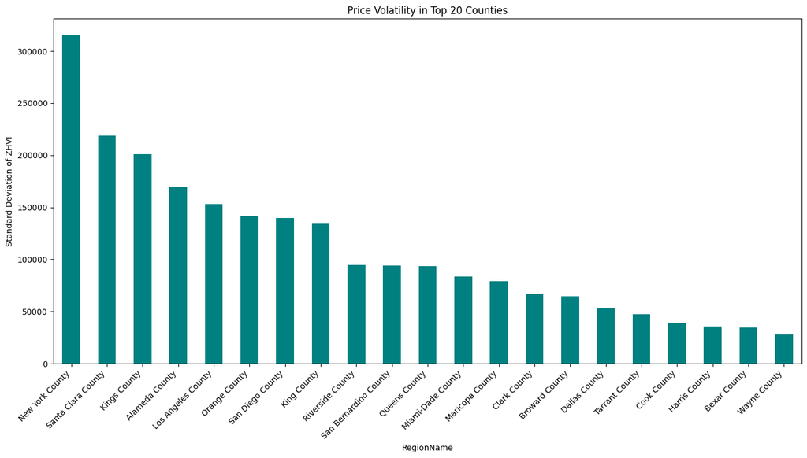

```python
# 2. Calculate and Visualize Volatility (Standard Deviation)
volatility = top_counties.groupby('RegionName')['ZHVI'].std().sort_values(ascending=False)
plt.figure(figsize=(14, 8))
volatility.plot(kind='bar', color='teal')
plt.title('Price Volatility in Top 20 Counties')
plt.ylabel('Standard Deviation of ZHVI')
plt.xticks(rotation=45, ha='right')
plt.tight_layout()
plt.show()
```

Year-over-Year Growth Analysis

Year-over-year (YoY) growth analysis helps identify how housing prices change annually across different counties. By extracting the year from each date and grouping the dataset accordingly, we calculate the average ZHVI values for each region in a given year. The percentage change between consecutive years is then computed to observe growth trends over time.

A heatmap visualization is used to represent these year-over-year growth patterns. Counties with consistent positive growth indicate a strong and appreciating housing market, while those with negative or fluctuating growth may suggest instability. This analysis allows real estate investors and policymakers to recognize high-growth regions and make informed strategic decisions regarding investments and housing policies.

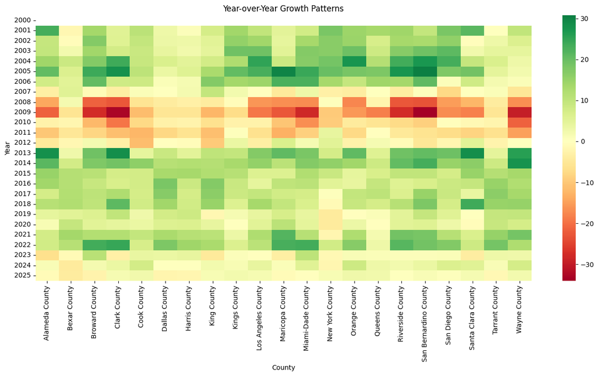

```python
# 3. Year-over-Year Growth Analysis
top_counties['Year'] = top_counties['Date'].dt.year
yoy_growth = top_counties.groupby(['RegionName', 'Year'])['ZHVI'].mean().unstack().pct_change(axis=1) * 100

plt.figure(figsize=(14, 8))
sns.heatmap(yoy_growth.T, cmap='RdYlGn', center=0, annot=False)
plt.title('Year-over-Year Growth Patterns')
plt.xlabel('County')
plt.ylabel('Year')
plt.tight_layout()
plt.show()
```

```
Peak Value Analysis:
```

| RegionName | Peak ZHVI | Peak Date | Days from Peak |
| --- | --- | --- | --- |
| New York County | 1.605544e+06 | 2017-08-31 | 2710 |
| Santa Clara County | 9.548109e+05 | 2022-06-30 | 946 |
| Kings County | 8.547908e+05 | 2025-01-31 | 0 |
| Alameda County | 7.891128e+05 | 2022-05-31 | 976 |
| Orange County | 7.470825e+05 | 2025-01-31 | 0 |

Distributions

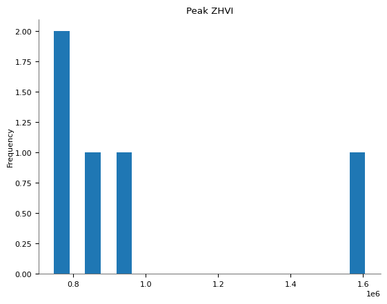

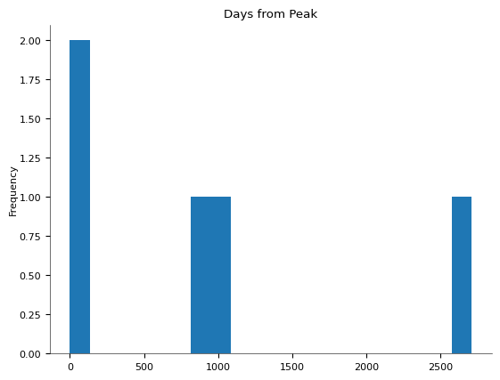

2-d distributions

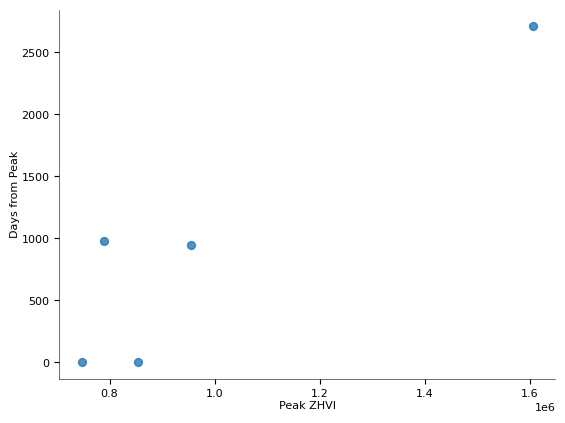

Time series

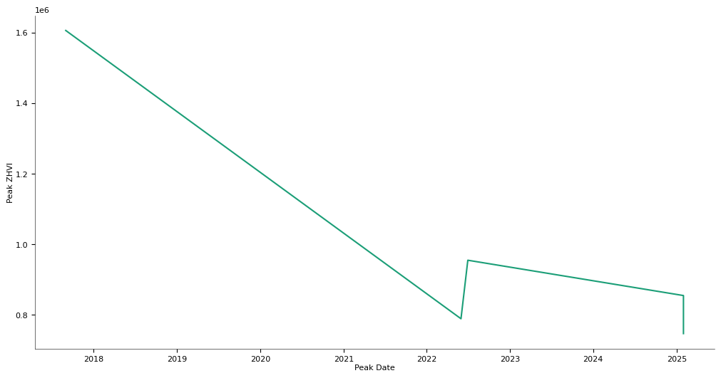

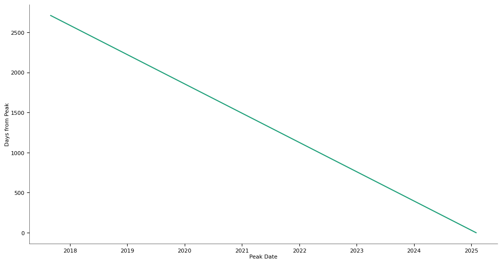

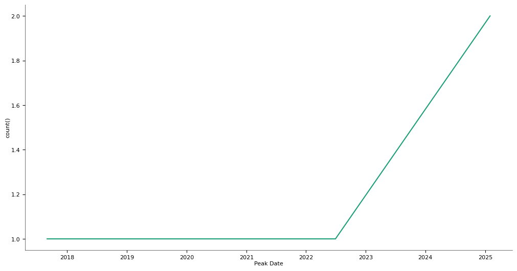

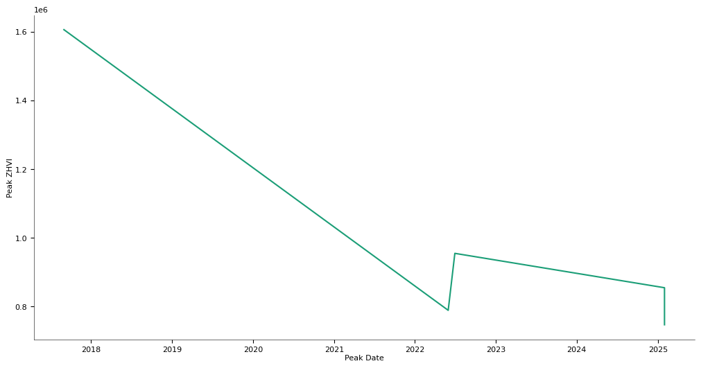

Values

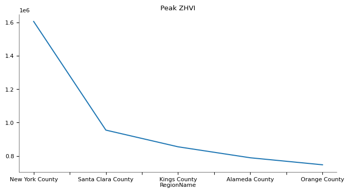

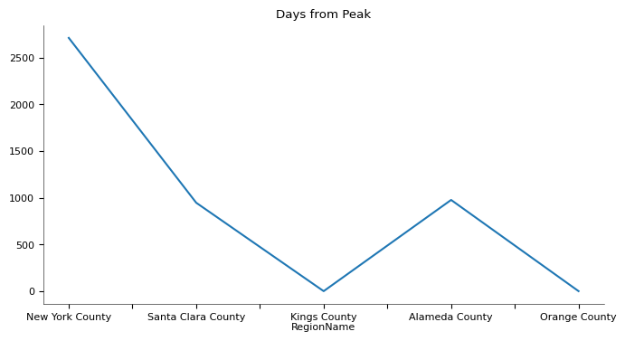

```python
# 4. Identify Peak Values and Timing
peak_values = top_counties.groupby('RegionName')['ZHVI'].max()
peak_dates = top_counties.groupby('RegionName').apply(lambda x: x.loc[x['ZHVI'].idxmax(), 'Date'])

peak_analysis = pd.DataFrame({
    'Peak ZHVI': peak_values,
    'Peak Date': peak_dates,
    'Days from Peak': (peak_dates.max() - peak_dates).dt.days
}).sort_values('Peak ZHVI', ascending=False)

print("Peak Value Analysis:")
display(peak_analysis.head())
```

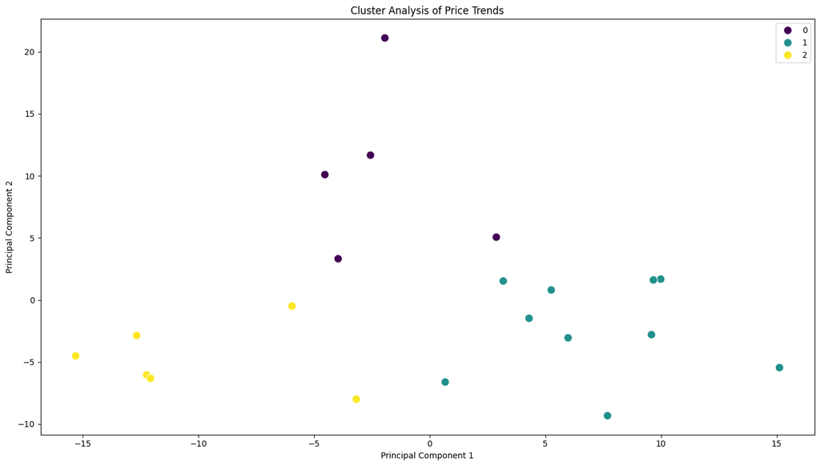

```python
# 5. KMeans Clustering of Price Trends
# Pivot data for clustering
pivot_df = top_counties.pivot(index='Date', columns='RegionName', values='ZHVI')
pct_change = pivot_df.pct_change().dropna()

# PCA for dimensionality reduction
scaler = StandardScaler()
scaled_data = scaler.fit_transform(pct_change.T)

pca = PCA(n_components=2)
principal_components = pca.fit_transform(scaled_data)

# KMeans clustering
kmeans = KMeans(n_clusters=3, random_state=42)
clusters = kmeans.fit_predict(principal_components)

# Visualize clusters
plt.figure(figsize=(14, 8))
sns.scatterplot(x=principal_components[:,0], y=principal_components[:,1],
                hue=clusters, palette='viridis', s=100)
plt.title('Cluster Analysis of Price Trends')
plt.xlabel('Principal Component 1')
plt.ylabel('Principal Component 2')
plt.tight_layout()
plt.show()
```

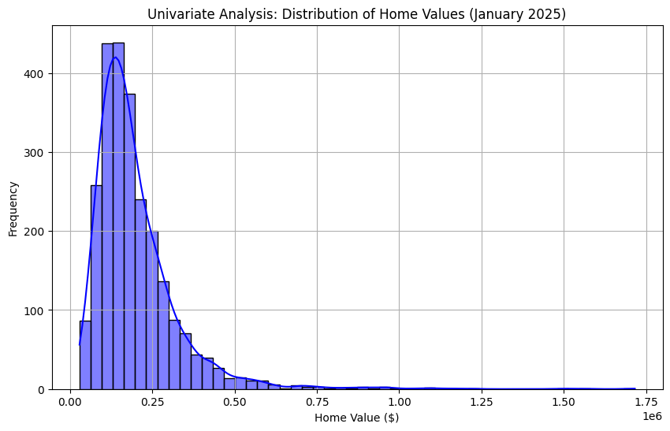

```python
# Univariate Analysis: Distribution of Home Values in January 2025

# Filter data for January 2025
january_2025_data = df_2020[df_2020['Date'] == '2025-01-31']['ZHVI']

plt.figure(figsize=(10, 6))

# Use the filtered data for the histogram
sns.histplot(january_2025_data, bins=50, kde=True, color="blue")

plt.xlabel("Home Value ($)")
plt.ylabel("Frequency")
plt.title("Univariate Analysis: Distribution of Home Values (January 2025)")
plt.grid(True)
plt.show()
```

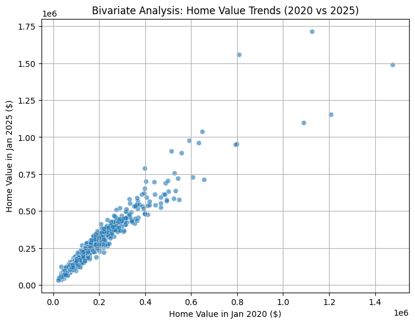

```python
# Bivariate Analysis: Scatter plot between Home Values in January 2020 and January 2025

# Assuming 'df_2020' contains the relevant data, filter it to include only the desired dates
df_filtered_2020 = df_2020[df_2020['Date'].isin(['2020-01-31', '2025-01-31'])]

# Pivot the data to have dates as columns
# Use pivot_table to handle duplicate entries by taking the mean
df_filtered_2020 = df_filtered_2020.pivot_table(index='RegionName', columns='Date', values='ZHVI', aggfunc='mean')


plt.figure(figsize=(8, 6))
sns.scatterplot(x=df_filtered_2020["2020-01-31"], y=df_filtered_2020["2025-01-31"], alpha=0.6)
plt.xlabel("Home Value in Jan 2020 ($)")
plt.ylabel("Home Value in Jan 2025 ($)")
plt.title("Bivariate Analysis: Home Value Trends (2020 vs 2025)")
plt.grid(True)
plt.show()
```